# Сетевые технологии

Лабораторная работа №2

Просина Ксения Максимовна

1132231845@pfur.ru

Российский университет дружбы народов

2026-03-18

# Информация

## Докладчик

- Просина Ксения Максимовна
- Студент 3 курса
- факультет физико-математических и естественных наук
- Российский университет дружбы народов им. П. Лумумбы
- 1132231938@rudn.ru

# Цель работы

## Цель работы

Изучение принципов технологий Ethernet и Fast Ethernet. Практическое освоение методик оценки работоспособности сети на базе технологии Fast Ethernet.

# Задание

## Задание

Оценить работоспособность 100-мегабитной сети Fast Ethernet для шести различных конфигураций по двум моделям анализа.

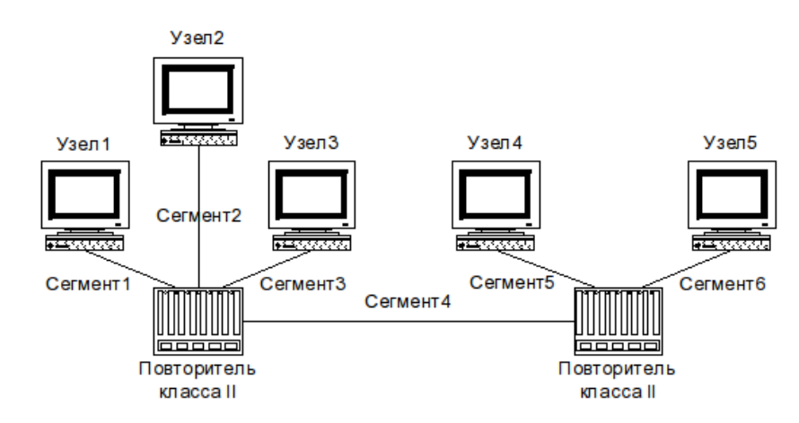

Топология сети Fast Ethernet

# Выполнение лабораторной работы

## Две модели анализа

Первая модель устанавливает структурные ограничения: максимальная длина сегмента и диаметр домена коллизий.

Вторая модель оценивает временные параметры передачи сигнала, проверяя время двойного оборота сигнала в сети.

## Исходные данные

Для анализа предоставлены шесть конфигураций сети, отличающихся длинами сегментов между узлами и повторителями.

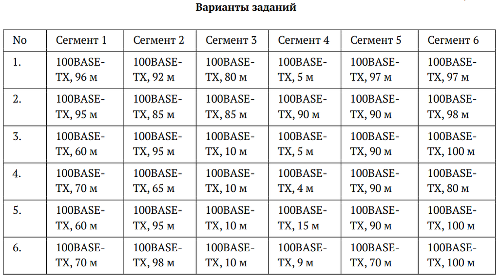

Таблица вариантов конфигураций сети

## Проверка по первой модели

Второе условие: диаметр домена коллизий должен быть меньше 205 метров.

## Проверка по второй модели

Вторая модель требует расчета времени двойного оборота сигнала по формуле: T = 100 + (L1 + L4 + L6) × 1,112 + 2 × 92 + 4.

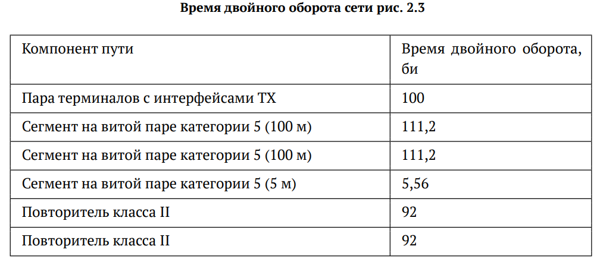

Пример расчёта времени двойного оборота

## Причины неработоспособности

Вариант 2 превышает допустимые значения как диаметра домена коллизий, так и времени двойного оборота сигнала.

## Методы исправления

Уменьшить длину сегментов, заменить повторитель на коммутатор или использовать кабель с меньшей задержкой.

# Выводы

# Ответы на вопросы

## Ответы на вопросы

1. Домен коллизий — группа узлов, конкурирующих за общую среду передачи.
2. Повторители класса I выполняют преобразование сигналов, класса II передают без преобразования.
3. Биттовый интервал 0,01 мкс соответствует скорости 100 Мбит/с.

# Заключение

## Заключение

Работа показала важность комплексного подхода к проектированию сетей Fast Ethernet.